# BIOS_sctransform-normalisation

Ruqian Lyu

11/30/2020

## sctransform

Different from the `size_factor`-based normalisation method that we used before, `sctransform` is based on probabilistic models for normalisation and variance stablisation of UMI-count data from scRNAseq. Instead of using a constant factor for normalising all genes for one cell, `sctransform` (Hafemeister and Satija 2019) models and scales each gene individually.

`sctransform` fits a generalised linear model with a negative binomial error model for each gene with the sequencing depth (library size) as a covariate followed by a regularisation procedure to control overfitting. The residuals from the regularised regression model is then treated as normalised expression levels with variation caused by sequencing depth removed.

```r
suppressPackageStartupMessages({
    library(sctransform)
    library(ggplot2)
    library(scater)
    library(scran)
  }
)
sce.pbmc <- readRDS(file = "untar_path/sce_pbmc.rds")
```

We use the `log10_umi` as the latent variable that will be regressed out in the normalised gene expression values.

```r
set.seed(10000)

colData(sce.pbmc)$log10_umi <- log(colData(sce.pbmc)$total,base=10)
pbmc.sctrans <- suppressWarnings(sctransform::vst(assay(sce.pbmc,"counts"),
                                 cell_attr = colData(sce.pbmc),
                                 latent_var = "log10_umi", verbosity = FALSE))

## Warning related issue: https://github.com/ChristophH/sctransform/issues/25
```

```r
#str(pbmc.sctrans)
```

## Add to assay field

`pbmc.sctrans` stores returned value from running variance stablisation using sctransform. The normalised values are stored in the matrix `y`. We now add `y` to the `sce` object in the assay field with asaay name “SCT”. This is equivalant to the `logcounts` assay.

```r
## Less genes will be returned by sctransform which filtered out genes that are
## only detected in 5 or less cells.
sce.pbmc <- sce.pbmc[rownames(pbmc.sctrans$y),]
assay(sce.pbmc,"SCT") <- pbmc.sctrans$y
```

## Select highly variable genes

Feature selection after `sctransform` normalisation is straightforward. We can just select the top genes that have a high residual variance which contribute the most biological sources of variation.

```r
head(round(pbmc.sctrans$gene_attr[order(-pbmc.sctrans$gene_attr$residual_variance), ], 2),
    22)
```

```
##           detection_rate gmean variance residual_mean residual_variance
## IGKC                0.27  0.60   184.08          2.89            135.91
## S100A8              0.62  2.15   633.20          3.75            125.33
## S100A9              0.70  2.70   921.73          3.68            113.23
## GNLY                0.24  0.45    74.24          2.05             96.29
## LYZ                 0.65  2.82  1042.16          3.70             82.80
## IGLC3               0.10  0.16   590.98          1.11             71.41
## IGLC2               0.19  0.26 16209.67          1.16             69.35
## NKG7                0.38  0.84    45.18          1.76             41.94
## PPBP                0.03  0.05    10.27          0.55             41.88
## PF4                 0.03  0.04     3.27          0.55             41.33
## CCL5                0.35  0.85    38.41          1.70             32.14
## SDPR                0.02  0.03     1.20          0.44             31.22
## GNG11               0.04  0.04     1.01          0.43             30.53
## HIST1H2AC           0.06  0.06     2.78          0.42             27.31
## GZMB                0.10  0.14     9.18          0.62             27.26
## TUBB1               0.02  0.03     1.27          0.39             27.14
## CD74                0.92  6.11  1597.07          1.75             26.45
## FTL                 0.99 12.79  1475.18          1.45             22.33
## JCHAIN              0.07  0.09    12.44          0.40             21.84
## S100A12             0.26  0.49    16.41          0.95             21.73
## KLRB1               0.24  0.46    15.92          0.99             21.64
## CST3                0.56  1.77   306.70          1.51             21.15
```

select 3,000 highly variable genes for downstream analysis

```r
hvgs_3k <- rownames(round(pbmc.sctrans$gene_attr[order(-pbmc.sctrans$gene_attr$residual_variance), ], 2),
    3000)
```

## runPCA with HVGs

Next, we runPCA with the selected number of highly variable genes.

```r
set.seed(10000)
sce.pbmc <- runPCA(sce.pbmc,exprs_values="SCT",ncomponents=10,
                   subset_row=hvgs_3k)
```

Generate TSNE plot using PCs

```r
set.seed(10000)
sce.pbmc <- runTSNE(sce.pbmc, dimred="PCA")
sce.pbmc <- runUMAP(sce.pbmc, dimred="PCA")
```

## Clustering

The remaining steps are similar to those presented in the main workflow.

```r
g <- buildSNNGraph(sce.pbmc, k=35, use.dimred = 'PCA')
clust <- igraph::cluster_walktrap(g)$membership
colLabels(sce.pbmc) <- factor(clust)
```

## Plot Clusters

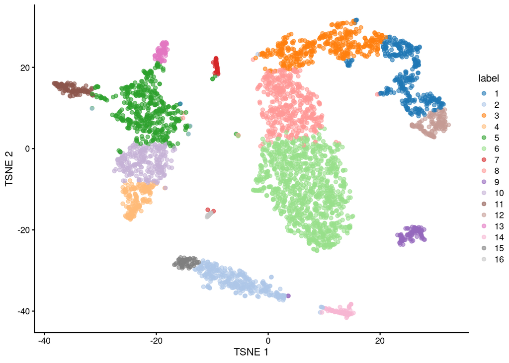

```r
plotTSNE(sce.pbmc, colour_by="label")
```

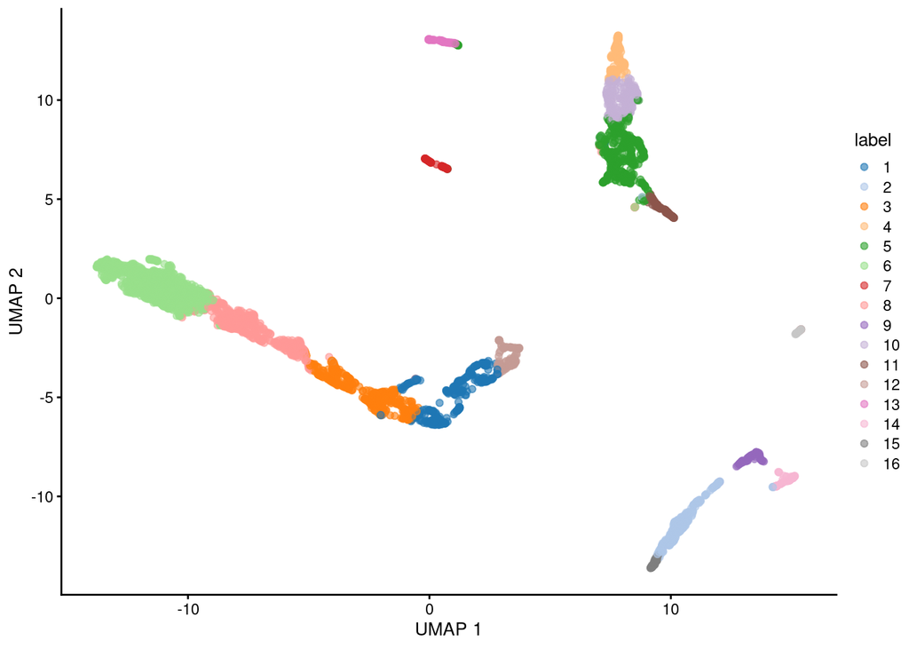

```r
plotUMAP(sce.pbmc, colour_by="label")
```

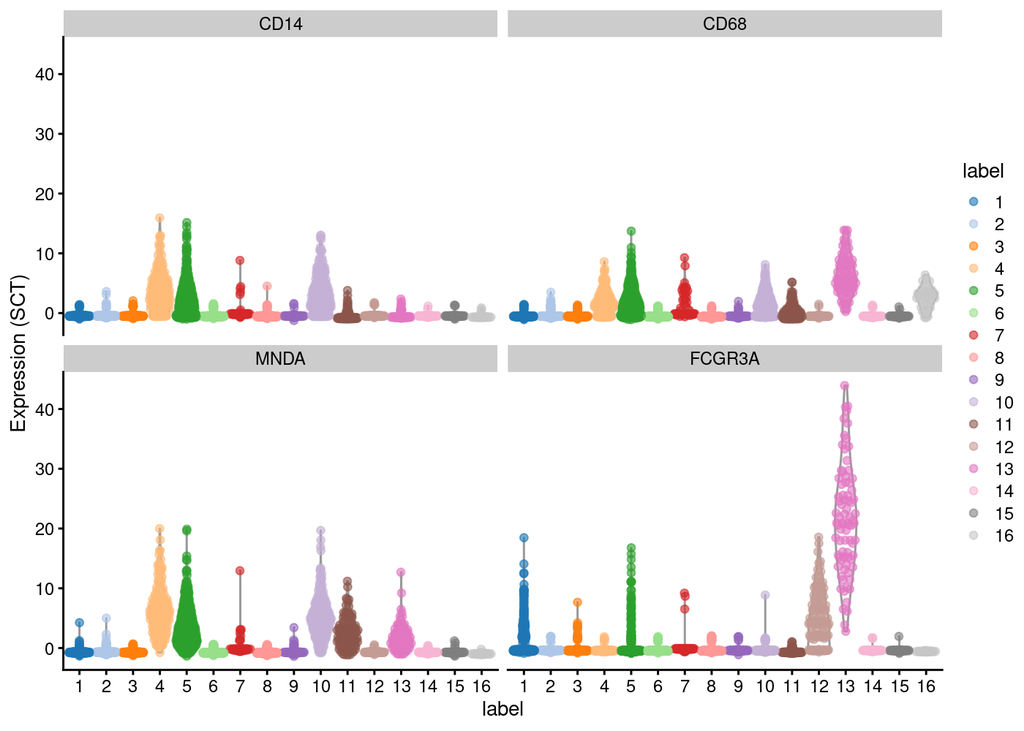

```r
plotExpression(sce.pbmc, features=c("CD14", "CD68",
    "MNDA", "FCGR3A"), x="label", colour_by="label",exprs_values = "SCT")
```

## More info

`sctransform` is also integrated and interfaced with `Seurat` package which you can find more information here: https://satijalab.org/seurat/v3.2/sctransform_vignette.html

## References

Hafemeister, Christoph, and Rahul Satija. 2019. “Normalization and Variance Stabilization of Single-Cell RNA-seq Data Using Regularized Negative Binomial Regression.” *Genome Biol.* 20 (1): 296.